# Prediction Assignment:Practical Machine learning

Divyanshu

12/10/2020

## Overview

in today’s world a lot of people are Using devices which monitors the day to day activities of the person for example Jawbone Up, Nike FuelBand, and Fitbit , this has made collection of large amount of data about personal activity relatively cheaper.this project analyse the way in which participants perform a barbell lift. The data comes from http://groupware.les.inf.puc-rio.br/har wherein a event is organised 6 participants perform the same set of exercises correctly and incorrectly with monitors set on the target area of the body and equipments.

## DATA

The training data is taken from:https://d396qusza40orc.cloudfront.net/predmachlearn/pml-training.csv The test data is taken from:https://d396qusza40orc.cloudfront.net/predmachlearn/pml-testing.csv

```r
  library(caret)
```

```r
library(rpart)
library(rpart.plot)
library(ggplot2)
library(corrplot)
library(randomForest)
library(rattle)
set.seed(21345)
```

## Data Loading

First, we load the training and testing set from the online sources and then split the training set further into training and test sets.

```r
training_URL <- "https://d396qusza40orc.cloudfront.net/predmachlearn/pml-training.csv"
testing_URL <- "https://d396qusza40orc.cloudfront.net/predmachlearn/pml-testing.csv"
tr_aining_data <- read.csv(url(training_URL))
te_sting_data <- read.csv(url(testing_URL))
la_bel <- createDataPartition(tr_aining_data$classe, p = 0.7, list = FALSE)
tr_ain <- tr_aining_data[la_bel, ]
te_st <- tr_aining_data[-la_bel, ]
```

## Data_cleaning_

there are 160 variables present in the dataset, some variables are there which has nearly zero variance and some contain a lot of NA terms. we need to exclude these terms.

```r
NZV <- nearZeroVar(tr_ain)
tr_ain <- tr_ain[ ,-NZV]
te_st <- te_st[ ,-NZV]
la_bel <- apply(tr_ain, 2, function(x) mean(is.na(x))) > 0.95
tr_ain <- tr_ain[, -which(la_bel, la_bel == FALSE)]
te_st <- te_st[, -which(la_bel, la_bel == FALSE)]
tr_ain <- tr_ain[ , -(1:5)] #other 5 identification variables  removed.
te_st <- te_st[ , -(1:5)]

dim(tr_aining_data)
```

```
## [1] 19622   160
```

```r
dim(te_sting_data)
```

```
## [1]  20 160
```

## Explortory An_alysis

Now we have cleaned our dataset and it’s free from absurd variables and all, Now to we should find relation among them by looking at the corelation plot.

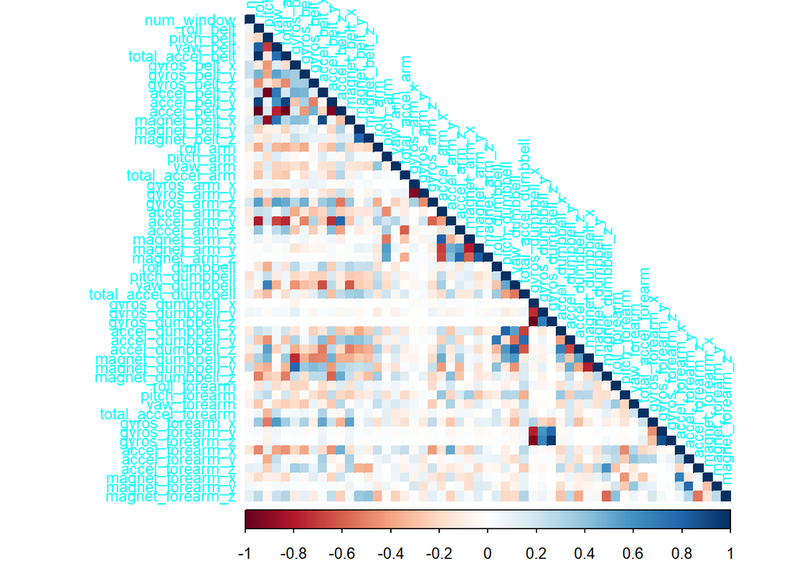

```r
corrMat <- cor(tr_ain[,-54])
corrplot(corrMat, method = "color", type = "lower", tl.cex = 0.8, tl.col = rgb(0,1,1))
```

In this plot gradient having dark colour represents high correlation . due to less number of correlation the need of using principal component analysis in order to reduce the correlated variables is rueled out.

## Decision Tree

Decision tree is a graph to represent choices and their results in form of a tree. The nodes in the graph represent an event or choice and the edges of the graph represent the decision rules or conditions. It is mostly used in Machine Learning and Data Mining applications using R. rpart():Recursive Partitioning And Regression Trees parameters formula, data, weights, subset, na.action , method.

```r
model1_DT <- rpart(classe ~ ., data = tr_ain, method = "class")
predict1_DT <- predict(model1_DT, te_st, type = "class")
confMat1_DT <- confusionMatrix(predict1_DT, te_st$classe)
confMat1_DT
```

```
## Confusion Matrix and Statistics
##
##           Reference
## Prediction    A    B    C    D    E
##          A 1419  141   13   57   51
##          B   60  634   43   64   67
##          C   16  144  827   97   24
##          D  171  214  143  693  154
##          E    8    6    0   53  786
##
## Overall Statistics
##
##                Accuracy : 0.7407
##                  95% CI : (0.7293, 0.7519)
##     No Information Rate : 0.2845
##     P-Value [Acc > NIR] : < 2.2e-16
##
##                   Kappa : 0.6728
##
##  Mcnemar's Test P-Value : < 2.2e-16
##
## Statistics by Class:
##
##                      Class: A Class: B Class: C Class: D Class: E
## Sensitivity            0.8477   0.5566   0.8060   0.7189   0.7264
## Specificity            0.9378   0.9507   0.9422   0.8614   0.9861
## Pos Pred Value         0.8441   0.7304   0.7464   0.5040   0.9215
## Neg Pred Value         0.9393   0.8993   0.9583   0.9399   0.9412
## Prevalence             0.2845   0.1935   0.1743   0.1638   0.1839
## Detection Rate         0.2411   0.1077   0.1405   0.1178   0.1336
## Detection Prevalence   0.2856   0.1475   0.1883   0.2336   0.1449
## Balanced Accuracy      0.8927   0.7537   0.8741   0.7901   0.8562
```

## Random Forest

In random forest approach a large number of decision trees are created. Every observation is given to every decision tree. The most common outcome for each observation is used as the final output. traincontrol():Control Parameters For Train parameters:method,repeats,number,p,search,initialWindow, horizon, fixedWindow, skip

```r
control_1 <- trainControl(method = "cv", number = 3, verboseIter=FALSE)
model1_RF <- train(classe ~ ., data = tr_ain, method = "rf", trControl = control_1)
predict1_RF <- predict(model1_RF, te_st)
confMat1_RF <- confusionMatrix(predict1_RF, te_st$classe)
confMat1_RF
```

```
## Confusion Matrix and Statistics
##
##           Reference
## Prediction    A    B    C    D    E
##          A 1673    1    0    0    0
##          B    1 1136    0    0    0
##          C    0    2 1026    2    0
##          D    0    0    0  962    4
##          E    0    0    0    0 1078
##
## Overall Statistics
##
##                Accuracy : 0.9983
##                  95% CI : (0.9969, 0.9992)
##     No Information Rate : 0.2845
##     P-Value [Acc > NIR] : < 2.2e-16
##
##                   Kappa : 0.9979
##
##  Mcnemar's Test P-Value : NA
##
## Statistics by Class:
##
##                      Class: A Class: B Class: C Class: D Class: E
## Sensitivity            0.9994   0.9974   1.0000   0.9979   0.9963
## Specificity            0.9998   0.9998   0.9992   0.9992   1.0000
## Pos Pred Value         0.9994   0.9991   0.9961   0.9959   1.0000
## Neg Pred Value         0.9998   0.9994   1.0000   0.9996   0.9992
## Prevalence             0.2845   0.1935   0.1743   0.1638   0.1839
## Detection Rate         0.2843   0.1930   0.1743   0.1635   0.1832
## Detection Prevalence   0.2845   0.1932   0.1750   0.1641   0.1832
## Balanced Accuracy      0.9996   0.9986   0.9996   0.9986   0.9982
```

## predicting the output

```r
predict1_RF <- predict(model1_RF, te_sting_data)
predict1_RF
```

```
##  [1] B A B A A E D B A A B C B A E E A B B B
## Levels: A B C D E
```